# Reproducible Research: Peer Assessment 1

```r
Sys.setlocale(category = "LC_ALL", locale = "English")
```

```
## [1] "LC_COLLATE=English_United States.1252;LC_CTYPE=English_United States.1252;LC_MONETARY=English_United States.1252;LC_NUMERIC=C;LC_TIME=English_United States.1252"
```

## Loading and preprocessing the data

Loading data and converting to proper formats.

```r
dataTable <- read.csv("activity.csv", colClasses = "character")
dataTable$steps <- as.numeric(dataTable$steps)
dataTable$date <- as.Date(dataTable$date, "%Y-%m-%d")
dataTable$interval <- as.numeric(dataTable$interval)
head(dataTable)
```

```
##   steps       date interval
## 1    NA 2012-10-01        0
## 2    NA 2012-10-01        5
## 3    NA 2012-10-01       10
## 4    NA 2012-10-01       15
## 5    NA 2012-10-01       20
## 6    NA 2012-10-01       25
```

Generate a list of unique dates from data.

```r
dateList <- sort(dataTable[!duplicated(dataTable[,"date"]),"date"])
summary(dateList)
```

```
##         Min.      1st Qu.       Median         Mean      3rd Qu.
## "2012-10-01" "2012-10-16" "2012-10-31" "2012-10-31" "2012-11-15"
##         Max.
## "2012-11-30"
```

Generate a list of unique intervals from data.

```r
intervalList <- sort(dataTable[!duplicated(dataTable[,"interval"]),"interval"])
summary(intervalList)
```

```
##    Min. 1st Qu.  Median    Mean 3rd Qu.    Max.
##     0.0   588.8  1178.0  1178.0  1766.0  2355.0
```

## What is mean total number of steps taken per day?

Histogram of steps:

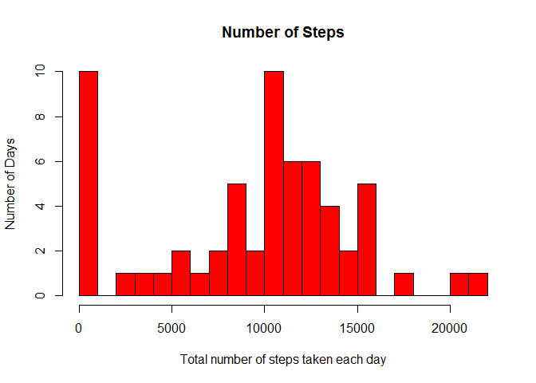

```r
dtStats <- data.frame(date = character(0), steps = numeric(0))
dtStats$date <- as.Date(dtStats$date, "%Y-%m-%d")

for(currentDate in dateList)
{
  dailySteps <- dataTable[currentDate == dataTable$date, "steps"]
  dailySum <- sum(dailySteps, na.rm = TRUE)

  tempDT <- data.frame(date = currentDate, steps = dailySum)
  tempDT$date <- as.Date(tempDT$date, origin="1970-01-01")

  dtStats <- rbind(dtStats, tempDT)
}

hist(dtStats$steps, breaks = 20, main="Number of Steps", xlab="Total number of steps taken each day", ylab = "Number of Days", col="red")
```

The mean number of steps:

```r
mean(dtStats$steps)
```

```
## [1] 9354.23
```

The median number of steps:

```r
median(dtStats$steps)
```

```
## [1] 10395
```

## What is the average daily activity pattern?

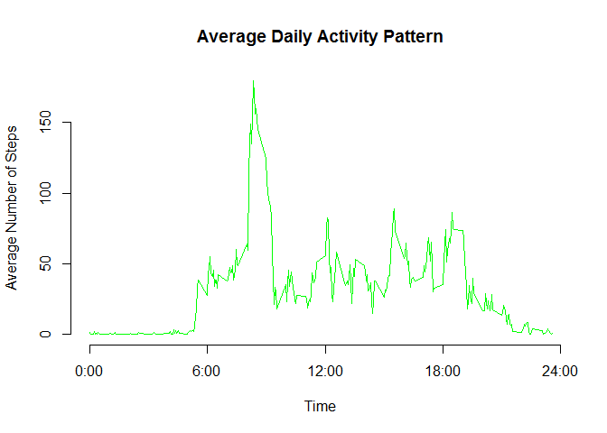

```r
count <- as.numeric(0)
daStats <- data.frame(interval = numeric(0), steps = numeric(0))

for(currentInterval in intervalList)
{
  count <- count + 1
  stepStore <- dataTable[currentInterval == dataTable$interval, "steps"]
  numInstanceInterval <- length(stepStore)
  avgSteps <- sum(stepStore, na.rm = TRUE) / numInstanceInterval

  tempDT <- data.frame(interval = currentInterval, steps = avgSteps)

  daStats <- rbind(daStats, tempDT)
}

plot(daStats$interval, daStats$steps,axes = F, type="l", col="green", xlab="Time", ylab="Average Number of Steps", main="Average Daily Activity Pattern")
axis(1,at=c(0,600,1200,1800,2400), label = c("0:00","6:00","12:00","18:00","24:00"))
axis(2)
```

```r
daStats[max(daStats$steps), "interval"]
```

```
## [1] 1450
```

## Imputing missing values

Number of NA Values:

```r
revDataTable <- dataTable

length(revDataTable[is.na(revDataTable$steps), "steps"])
```

```
## [1] 2304
```

Strategy: Daily averages were used to fill the NA values whenever daily averages are avaliable. If daily averages are not avaliable, the averages of the 5 minute time slot across all dates for the time slot having the NA value is used.

Creating a new dataset that is equal to the original dataset but with the missing data filled in.

```r
for(currentDate in dateList)
{
  dailySteps <- revDataTable[currentDate == revDataTable$date, "steps"]
  numDailySteps <- length(dailySteps[!is.na(dailySteps)])
  if(numDailySteps > 0)
  {
    revDataTable[(currentDate == revDataTable$date) & is.na(revDataTable$steps), "steps"] <- dtStats[(currentDate == dtStats$date), "steps"] / numDailySteps
  }
}

for(currentInterval in intervalList)
{
  intervalSteps <- revDataTable[currentInterval == revDataTable$interval, "steps"]
  numIntervalSteps <- length(intervalSteps[!is.na(intervalSteps)])

  revDataTable[(currentInterval == revDataTable$interval) & is.na(revDataTable$steps), "steps"] <- daStats[(currentInterval == daStats$interval), "steps"]
}

revStats <- data.frame(date = character(0), steps = numeric(0))
revStats$date <- as.Date(revStats$date, "%Y-%m-%d")

for(currentDate in dateList)
{
  dailySteps <- revDataTable[currentDate == revDataTable$date, "steps"]
  dailySum <- sum(dailySteps, na.rm = TRUE)

  tempDT <- data.frame(date = currentDate, steps = dailySum)
  tempDT$date <- as.Date(tempDT$date, origin="1970-01-01")

  revStats <- rbind(revStats, tempDT)
}
head(revStats)
```

```
##         date    steps
## 1 2012-10-01  9354.23
## 2 2012-10-02   126.00
## 3 2012-10-03 11352.00
## 4 2012-10-04 12116.00
## 5 2012-10-05 13294.00
## 6 2012-10-06 15420.00
```

Histogram of the total number of steps taken each day:

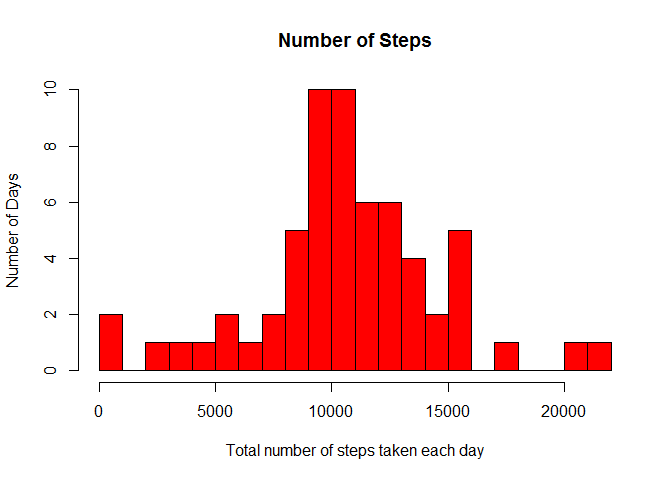

```r
hist(revStats$steps, breaks = 20, main="Number of Steps", xlab="Total number of steps taken each day", ylab = "Number of Days", col="red")
```

The revised mean is:

```r
mean(revStats$steps)
```

```
## [1] 10581.01
```

The revised median is:

```r
median(revStats$steps)
```

```
## [1] 10395
```

The impact of imputing missing data increased the mean of the total daily number of steps while the median of the total daily number of steps remained the same.

## Are there differences in activity patterns between weekdays and weekends?

Label each day as weekend or weekday.

```r
numrows <- length(dateList)
dateDT <- data.frame(date = numeric(numrows), weekdays = character(numrows), daytype = character(numrows))
dateDT$date <- as.Date(dateList, origin="1970-01-01")
dateDT$weekdays <- weekdays(as.Date(dateDT$date))
dateDT$daytype <- ifelse(dateDT$weekdays %in% c("Saturday", "Sunday"),"Weekend", "Weekday")
revDataTable <- merge(revDataTable, dateDT, "date")
head(revDataTable)
```

```
##         date      steps interval weekdays daytype
## 1 2012-10-01 1.49180328        0   Monday Weekday
## 2 2012-10-01 0.29508197        5   Monday Weekday
## 3 2012-10-01 0.11475410       10   Monday Weekday
## 4 2012-10-01 0.13114754       15   Monday Weekday
## 5 2012-10-01 0.06557377       20   Monday Weekday
## 6 2012-10-01 1.81967213       25   Monday Weekday
```

Calcluating the average for each interval of each day type.

```r
avgIntervalByDay <- aggregate(revDataTable$steps, by=list(revDataTable$interval, revDataTable$daytype), mean)
colnames(avgIntervalByDay)[1] <- "interval"
colnames(avgIntervalByDay)[2] <- "daytype"
colnames(avgIntervalByDay)[3] <- "meansteps"
head(avgIntervalByDay)
```

```
##   interval daytype  meansteps
## 1        0 Weekday 2.22112933
## 2        5 Weekday 0.43934426
## 3       10 Weekday 0.17085610
## 4       15 Weekday 0.19526412
## 5       20 Weekday 0.09763206
## 6       25 Weekday 1.55373406
```

```r
tail(avgIntervalByDay)
```

```
##     interval daytype   meansteps
## 571     2330 Weekend  1.34528689
## 572     2335 Weekend 11.51024590
## 573     2340 Weekend  6.23360656
## 574     2345 Weekend  1.69467213
## 575     2350 Weekend  0.02459016
## 576     2355 Weekend  0.11680328
```

Creating the plot of the average for each interval of each day type.

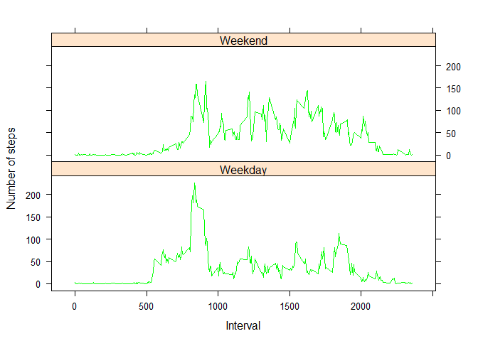

```r
library(lattice)
xyplot(meansteps ~ interval | daytype, data = avgIntervalByDay, layout = c(1, 2), type="l", xlab = "Interval", ylab = "Number of steps", col="green")
```